# NCI-60 BPO vs Leukemia Analysis

Jalal Siddiqui

7/19/2017

## Introduction

This vignette describes the analysis of NCI-60 data sets using IntLIM. We compare the breast/prostate/ovarian cancers with leukemia and look for gene-metabolite correlations that significantly differ based on cancer type. The following packages are needed.

```r
rm(list = ls())
library(RColorBrewer)
library(pheatmap)
library(IntLim)
library(MultiDataSet)
```

## Loading Data using IntLIM

```r
inputData <- IntLim::ReadData('nci60.csv',metabid='id',geneid='id')
```

```
## [1] "CreateMultiDataSet created"
```

```r
IntLim::OutputStats(inputData)
```

```
##   Num_Genes Num_Metabolites Num_Samples_withExpression
## 1     17987             280                         57
##   Num_Samples_withExpression.1 Num_Samples_inCommon
## 1                           58                   57
```

We plan to filter the gene expression data by removing the genes with the lowest mean expression at the 10th percentile. This reduces the total genes from 17,987 to 16,188.

```r
inputDatafilt <- IntLim::FilterData(inputData,geneperc=10)
```

```
## [1] "No metabolite filtering applied"
```

```r
IntLim::OutputStats(inputDatafilt)
```

```
##   Num_Genes Num_Metabolites Num_Samples_withExpression
## 1     16188             280                         57
##   Num_Samples_withExpression.1 Num_Samples_inCommon
## 1                           58                   57
```

## Distribution of Gene and Metabolite Data

The distribution of the NCI-60 cell line data is shown below. We can see that it is log2 transformed as well.

```r
IntLim::PlotDistributions(inputDatafilt)
```

[interactive chart not shown]

## Principal Component Analysis

The principal component analysis is run as follows.

```r
#PlotPCA(inputDatafilt, stype = 'cancergroup')
#Error
```

```r
IntLim::PlotPCA(subset(MultiDataSet::commonSamples(inputDatafilt), , cancergroup == 'Leukemia' | cancergroup == 'BPO'), stype = 'cancergroup')
```

[interactive chart not shown]

## Running Linear Model

The linear model is run as below. “cancergroup” is selected as the stype as we will be dividing groups based on androgen cancers vs leukemia. RunIntLim will calculate p-values for the (g:t) interaction term describing how the gene-metabolite relationship varies based on cancer type.

```r
myres <- IntLim::RunIntLim(inputDatafilt,stype="cancergroup")
```

```
## [1] "Running the analysis on"
## mp
##      BPO Leukemia
##       14        6
## [1] "10 % complete"
## [1] "20 % complete"
## [1] "30 % complete"
## [1] "40 % complete"
## [1] "50 % complete"
## [1] "60 % complete"
## [1] "70 % complete"
## [1] "80 % complete"
## [1] "90 % complete"
##    user  system elapsed
## 122.085   1.860 123.969
```

```r
#IntLim::DistPvalues(myres)
```

```r
#IntLim::DistPvalues(myres)
#Get Error
```

```r
myres <- IntLim::ProcessResults(myres,inputDatafilt, diffcorr = 0, pvalcutoff = 0.10)
IntLim::CorrHeatmap(myres)
```

[interactive chart not shown]

Another heatmap can be plotted using pheatmap. This allows for clustering of gene-metabolite pairs.

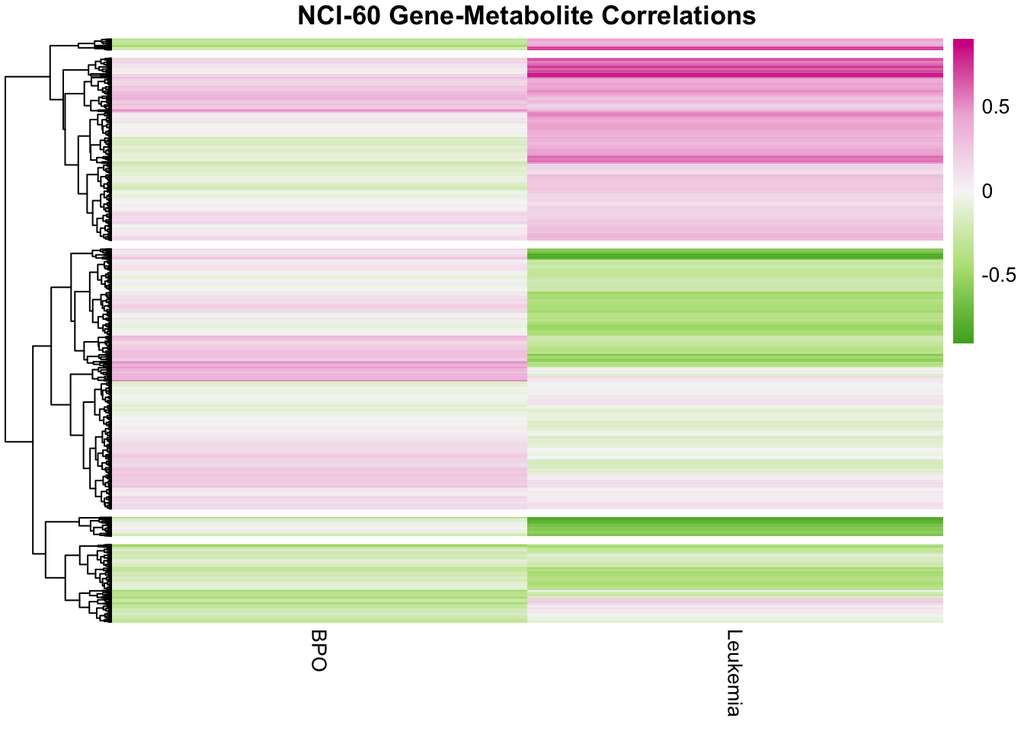

```r
mycols=colorRampPalette(brewer.pal(5,"PiYG")) (255)[255:1]

myheat=pheatmap(myres@corr[,c(3,4)],col=mycols,cutree_rows=5,
main="NCI-60 Gene-Metabolite Correlations", show_rownames = F, cluster_cols = FALSE)
```